# 第 13 章 模型可解释性

本章介绍一系列模型解释技术，帮助读者理解模型如何把输入转化为输出。Molnar (2019) 的专著（可在线阅读：https://christophm.github.io/interpretable-ml-book/）系统讨论了这一主题，值得深入阅读；Belle 和 Papantonis (2020) 的综述也很有参考价值。若希望先从入门材料读起，可参阅技术难度较低的 Hall 和 Gill (2019)。本章将从因子投资的视角出发，讨论如何解释基于金融数据训练的机器学习模型。

用于解释机器学习模型的定量工具应满足两个基本条件：

1. 能够揭示模型的信息；
2. 解释结果容易理解。

这类工具通常以直观的图形呈现结果，便于读者快速理解并作出判断。

在尝试打开复杂机器学习模型的“黑箱”时，最重要的一种区分是：

- **全局解释**旨在模型训练完成后，衡量各特征对预测结果的相对作用。它描述的是在整个训练集上平均成立的规律。
- **局部解释**通过考察某个具体样本附近的微小变化，刻画模型在该样本邻域内的行为。观察原模型如何处理这些扰动后，可以用较简单的模型（例如线性模型）作局部近似，并据此判断原始样本附近各相关特征影响的方向和大小。

Molnar（2019）还提出了另一种分类：一类解释方法依赖特定模型，如线性回归或决策树；另一类方法与模型无关，可用于解释任意模型。下文按照全局解释与局部解释的划分介绍这些方法。

## 13.1 全局解释

### 13.1.1 作为代理模型的简单模型

让我们从最简单的例子开始。在线性模型中，

\begin{align} y_i=\alpha+\sum_{k=1}^K\beta_kx_i^k+\epsilon_i, \end{align}

通常从 $\beta_k$ 的估计中提取以下元素：

- $R^2$，用于衡量模型的**整体拟合程度**。为避免预测变量过多造成过拟合，也可以采用带惩罚的版本。$R^2$ 通常在样本内计算；
- 估计值 $\hat{\beta}_k$ 的符号，用于表示特征 $x^k$ 对 $y$ 影响的**方向**；
- $t$ 统计量 $t_{\hat{\beta_k}}$，用于衡量系数估计相对于其标准误的大小，也就是该系数偏离零的**统计证据**，而不是经济影响本身的大小。实际分析中还常在适当的分布假设下，把 $t$ 统计量换算为 $p$ 值。

系数符号与统计量分别提供作用方向和统计证据；若要比较经济影响大小，还需要同时考虑系数尺度、特征量纲和估计不确定性。由此可以简化地展示模型如何把特征映射为输出。多数黑箱解释工具也沿用了“方向加贡献大小”的基本思路。

决策树容易可视化，因此也是天然具有可解释性的模型，并常被用作简单模型的基准。Vidal、Pacheco 和 Schiffer (2020) 提出了一种把树集成压缩为单棵树的方法，目标是得到一个行为与复杂模型一致、但结构更简单的模型。

更一般地说，可以用简单模型近似复杂算法，这类简单模型称为**代理模型**（surrogate model）。基本步骤如下：

先训练原始模型 $f$，输入为特征 $\textbf{X}$ 和标签 $\textbf{y}$；再训练一个更简单的模型 $g$，用它解释已训练模型 $\hat{f}$ 在给定特征 $\textbf{X}$ 时的预测：

\begin{align} \hat{f}(\textbf{X})=g(\textbf{X})+\textbf{error} \end{align}

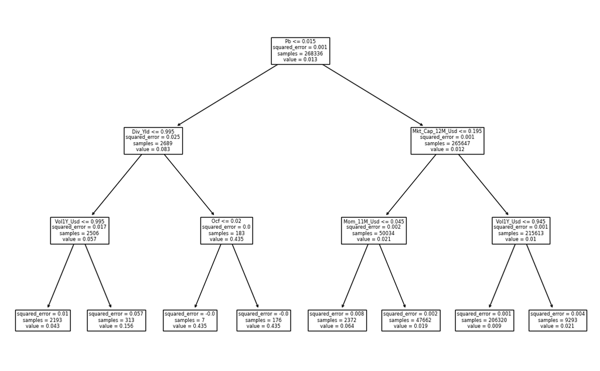

```python
new_target = fit_RF.predict(X_short)                                                    # saving the predictions of tree as new target
decision_tree_model = tree.DecisionTreeRegressor(max_depth=3)                           # defining the global interpretable tree surrogate model
TreeSurrogate=decision_tree_model.fit(X_short,new_target)               # fitting the surrogate
fig, ax = plt.subplots(figsize=(13, 8))                                                 # setting the chart parameters
tree.plot_tree(TreeSurrogate,feature_names=features_short, ax=ax)
plt.show()                                                                              # Plot!
```

图 13.1：代理树示例。

这棵树的呈现方式与第 6 章不同，但仍较好地概括了被模仿模型的主要复杂结构。

### 13.1.2 特征重要性（基于树）

简单决策树的一大优势是可解释性强：其图形结构清晰直观。与回归模型一样，简单决策树容易理解，不会像更复杂的工具那样受到“黑箱”质疑。

随机森林和提升树都无法完整、准确地展示模型内部的每一步计算。不过，模型训练完成后，可以汇总计算各特征在树结构形成过程中的贡献，也就是特征重要性。

训练完成后，对每个非叶节点 $n$，都可以计算下一次分裂带来的增益 $G(n)$，也可以确定该次分裂使用了哪个变量。记 $\mathcal{N}_k$ 为所有使用特征 $k$ 进行分裂的节点集合，则该特征的全局重要性为

\begin{align} I(k)=\sum_{n\in \mathcal{N}_k}G(n), \end{align}

实际使用时通常会对 $I(k)$ 重新缩放，使其在所有 $k$ 上的总和等于 1。此时，$I(k)$ 表示特征 $k$ 在训练过程中降低损失的相对贡献；它依赖训练样本、树算法和分裂准则，不提供作用方向，也不具有因果含义。重要性较高的特征往往更靠近树根。

下面回顾第 6 章训练的树模型，并复用其中三个回归模型的输出。需要注意，不同模型的拟合结果结构不同，保存特征重要性的向量名称也不相同。

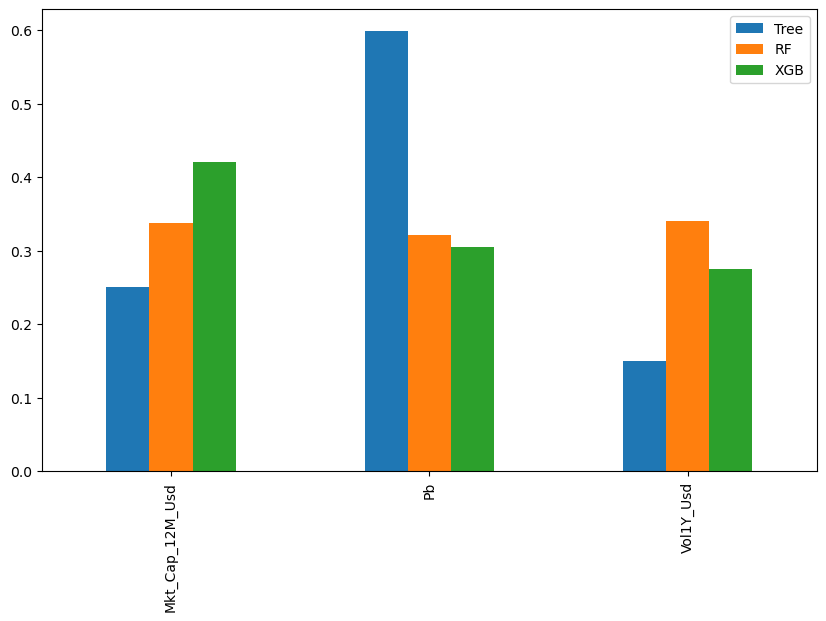

```python
tree_VI = pd.DataFrame(data=fit_tree.feature_importances_,index=features_short,columns=['Tree'])    # VI from tree model
RF_VI = pd.DataFrame(data=fit_RF.feature_importances_,index=features_short,columns=['RF'])          # VI from random forest
XGB_VI = pd.DataFrame(data=fit_xgb.feature_importances_,index=features_short,columns=['XGB'])       # VI from boosted trees
VI_trees=pd.concat([tree_VI,RF_VI,XGB_VI],axis=1)                                                   # Aggregate the VIs
VI_trees=VI_trees.loc[['Mkt_Cap_12M_Usd','Pb','Vol1Y_Usd']]/np.sum(VI_trees.loc[['Mkt_Cap_12M_Usd','Pb','Vol1Y_Usd']])
VI_trees.plot.bar(figsize=[10,6])                                                                   # Plotting sequence
```

图 13.2：基于树的模型的特征重要性。

受绘图方式影响，图 13.2 可能造成误解。简单决策树按其结构只会给少数特征赋予非零重要性；上图中只有市值、市净率和波动率三个特征。随机森林和提升树更复杂，会为更多预测变量分配一定的重要性。图中仅展示简单树涉及的变量，并在选定这一特征子集后再做归一化，以免变量过多影响可读性。

不同模型依赖特征的方式并不相同。例如，最重要的特征会随模型而变：简单树最重视市净率，随机森林更依赖波动率，提升树则为市值赋予更高权重。

随机森林的一个典型特点，是让所有特征都有机会参与模型。由于分裂候选变量是随机选取的，每个外生变量都可能用于解释标签。与把大部分重要性集中在少数特征上的简单树相比，随机森林和提升树在各预测变量之间分配的重要性通常更均衡。

## 13.1.3 特征重要性（模型无关）

特征重要性的思想也可以扩展到非树模型。关于这一研究方向，可参阅 Fisher、Rudin 和 Dominici (2019) 及其引用的文献。这里的目标是量化模型预测性能对每项特征所含信息的依赖程度，而不是识别该特征对标签的因果效应。

衡量模型预测对某个特征依赖程度的一种方法，是把样本中该特征的取值完全打乱，再观察模型表现如何变化。如果模型确实依赖该特征所含信息，打乱后模型损失应明显上升。特征高度相关时，其他特征可能替代被置换特征，使重要性被低估；置换也可能产生偏离原始联合分布的样本。

一般情况下评估特征重要性的基线方法如下：

先在原始数据上训练模型，并计算相应损失 $l^∗$。然后针对每个特征 $k$ 创建一份新训练数据，其中只随机打乱该特征的取值，再用这份扰动后的样本评估模型损失 $l_k$。最后，以差值 $\text{VI}_k=l_k-l^*$ 或比率 $\text{VI}_k=l_k/l^*$ 计算并排序各特征的重要性。

```python
from sklearn.linear_model import Ridge
import random

y_penalized = data_ml['R1M_Usd'].values # Dependent variable
X_penalized = data_ml[features].values # Predictors

fit_ridge_0 = Ridge(alpha=0.01)                                                         # Trained model
fit_ridge_0.fit(X_penalized_train, y_penalized_train)                                   # Fit model
l_star= np.mean(np.square(fit_ridge_0.predict(X_penalized_train)-y_penalized_train))    # Loss
```

接下来依次打乱每个预测变量，并评估相应损失。为节省计算时间，这里只进行一轮随机置换。

```python
from collections import Counter

res = []                                                                                                     # Initialize
feature_random = random.sample(list((Counter(features)-Counter(features_short)).elements()), 12)             # selecting fewer features for computation time sake
for feat in (features_short+feature_random):                                                                 # Loop on the features
    temp_data=training_sample[features].copy()                                                               # temp dataframe for all features
    temp_data.loc[:,feat] = np.random.permutation(training_sample[feat])                                     # shuffling for feat[i]
    fit_ridge_0.fit(temp_data[features], training_sample['R1M_Usd'])                                         # fitting the model
    result_VI=pd.DataFrame([feat],columns=['feat'])
    result_VI['loss']=[np.mean(np.square(fit_ridge_0.predict(temp_data[features])-training_sample['R1M_Usd'])) - l_star] # Loss
    res.append(result_VI)                                                                                    # appending through features loop
res = pd.concat(res)
res.set_index('feat',inplace=True)
```

最后，我们绘制结果。

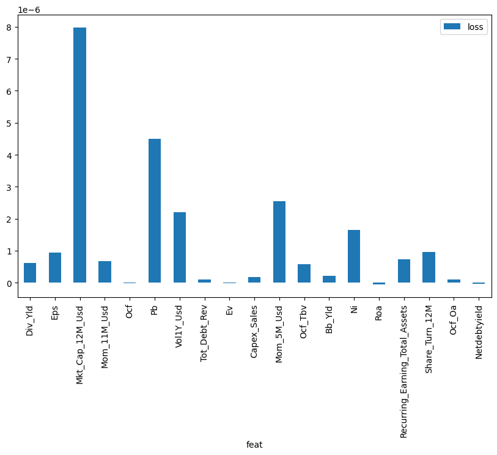

```python
res.plot.bar(figsize=[10,6])
```

图 13.3：岭回归模型的特征重要性。

### 13.1.4 部分依赖图

部分依赖图（PDP）用于展示模型输出与某个特征取值之间的关系。关于这一方法的早期讨论，可参阅 Friedman (2001) 第 8.2 节。

固定一个特征 $k$，我们的目标是考察特征 $k$ 取值变化时，已训练模型 $\hat{f}$ 的**平均响应**。为此，将特征空间分为两部分：目标特征 $k$ 与其余特征 $−k$，后者表示除 $k$ 之外的所有特征。部分依赖函数定义为

\begin{equation} \tag{13.1} \bar{f}_k(x_k)=\mathbb{E}[\hat{f}(\textbf{x}_{-k},x_k)]=\int \hat{f}(\textbf{x}_{-k},x_k)d\mathbb{P}_{-k}(\textbf{x}_{-k}), \end{equation}

其中 $d\mathbb{P}_{-k}(\cdot)$ 是其余特征 $\textbf{x}_{-k}$ 的多元分布。上述函数以特征值 $x_k$ 为参数，并按照其他特征的边际分布取平均，从而得到特征 $k$ 对模型预测的平均响应。若目标特征与其他特征高度相关，这种替换可能生成数据中很少出现甚至不可能出现的特征组合，因此 PDP 需要谨慎解读。实践中通常用蒙特卡罗模拟估计这一均值：

\begin{equation} \tag{13.2} \bar{f}_k(x_k)\approx \frac{1}{M}\sum_{m=1}^M\hat{f}\left(x_k,\textbf{x}_{-k}^{(m)}\right), \end{equation}

其中 $\textbf{x}_{-k}^{(m)}$ 是从其余特征的联合分布中独立抽取的样本。

理论上可以同时针对多个特征计算 PDP。实践中通常最多考察两个特征，此时得到一个三维曲面，而且计算量会明显增加。

下面用 scikit-learn 演示这一概念。待解释的模型是第 6.2 节构建的随机森林，并复用该节的一些变量。这里考察市净率对模型输出的影响。

```
<sklearn.inspection._plot.partial_dependence.PartialDependenceDisplay at 0x2abb7384df0>
```

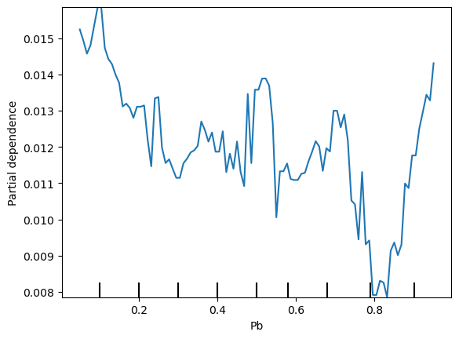

```python
from sklearn.inspection import PartialDependenceDisplay
PartialDependenceDisplay.from_estimator(fit_RF,training_sample[features_short], ['Pb'],kind='average')
```

图 13.4：随机森林模型市净率的部分依赖图。

PDP 通常只描述模型中的关联结构，不能自动作因果解释。关于在何种识别假设下可以赋予其因果含义，可参阅 Zhao 和 Hastie（2020）的理论讨论。

## 13.2 局部解释

全局解释考察特征对模型输出的整体影响，局部方法则刻画模型对某个具体样本或其邻域的行为。近年来，局部可解释性受到广泛关注，相关研究大量涌现。下面介绍其中最常用的几种方法。

### 13.2.1 LIME

LIME（Local Interpretable Model-Agnostic Explanations，局部可解释的模型无关解释）由 Ribeiro、Singh 和 Guestrin (2016) 提出，目标是在满足以下两个条件的前提下忠实解释模型：

- **解释简单**：只展示少量变量，并用图形或文字呈现，确保读者容易理解；
- **局部保真性**：解释应在待解释样本的邻域内忠实反映原模型。

设原始黑箱模型为 $f$，希望在具体样本 $x$ 附近用可解释模型 $g$ 近似其行为。简单函数 $g$ 属于候选模型集合 $G$，$x$ 的邻域记为 $pi_x$，$g$ 的复杂度记为 $\Omega(g)$。LIME 寻找如下形式的解释：

\begin{align} \xi(x)=\underset{g \in G}{\text{argmin}} \, \mathcal{L}(f,g,\pi_x)+\Omega(g), \end{align}

其中，$\mathcal{L}(f,g,\pi_x)$ 衡量 $g$ 在邻域 $\pi_x$ 内近似样本 $x$ 附近的原模型时产生的误差；惩罚项 $\Omega(g)$ 则控制解释模型的复杂度，例如树的叶节点数或深度、线性回归中的预测变量数量。

下面具体定义这些量。$x$ 的邻域权重为 $\pi_x(z)=e^{-D(x,z)^2/\sigma^2}$，其中 $D$ 是距离度量，$\sigma^2$ 是尺度常数。随着 $z$ 远离 $x$，该权重会逐渐减小。

关键在于损失函数的构造。LIME 会在 $x$ 附近生成一批人工样本，并汇总简单模型在这些样本上的预测误差。为简化记号，假设 $f$ 的输出是标量，则损失写为：

\begin{align} \mathcal{L}(f,g,\pi_x)=\sum_z \pi_x(z)(f(z)-g(z))^2 \end{align}

各样本的误差按其与原始样本 $x$ 的距离加权，距离越近，权重越大。在最基本的实现中，候选模型集合 $G$ 由线性模型构成。

图 13.5 用一个简化示意图说明 LIME 的工作原理。

[figure not shown]

图 13.5：LIME 的简化示意图。待解释样本由红色方框标出；模型在其附近生成五个点（三角形），并据此拟合加权线性模型（灰色虚线）。

为便于说明，这里只考虑一个预测变量。黑点表示原始训练样本，蓝线表示已训练模型给出的平滑条件均值。红色方框标出待解释的具体样本，我们希望近似模型在其附近的行为。为此，在该样本周围抽取 5 个新点，即图中的红色三角形。每个三角形都位于蓝线上，表示原模型的预测；三角形大小表示权重，离原始样本越近，权重越大。随后用加权最小二乘法对这 5 个点拟合线性模型，得到灰色虚线。该局部近似给出截距和斜率两个参数，二者都可用标准统计检验评估。

斜率的符号尤其重要。若待解释样本更靠近 $x=0$，局部斜率可能接近于零，此时该预测变量在这一邻域内几乎不起作用。另一个关键因素是采样点数量。示意图中只有 5 个点，但稳健估计在实践中通常需要约 1,000 个甚至更多邻域样本。样本过少会增大估计风险，使局部近似不够准确。

下面给出一个实现示例，分为三个步骤：

1. 在训练数据上拟合模型；
2. 使用 lime() 函数封装模型；
3. 选取少量预测变量，通过 explain() 函数考察它们对若干具体样本的影响。

我们从第一步开始。这次，我们使用提升树模型。

```python
import lime                                    # Package for LIME interpretation
import lime.lime_tabular

xgb_model = xgboost.XGBRegressor(              # Parameters of the boosted tree
    max_depth=5,                               # Max depth of each tree
    learning_rate=0.5,                         # Learning rate
    objective='reg:squarederror',              # booster type of objective function
    subsample=1,                               # Proportion of instance to be sampled (1 = all)
    colsample_bytree=1,                        # Proportion of predictors to be sampled (1 = all)
    gamma=0.1,                                 # Penalization
    n_estimators=10,                           # Number of trees
    min_child_weight=10)                       # Min number of instances in each node

xgb_model.fit(train_features_xgb, train_label_xgb) # Training of the model
```

```
XGBRegressor(base_score=0.5, booster='gbtree', callbacks=None,
             colsample_bylevel=1, colsample_bynode=1, colsample_bytree=1,
             early_stopping_rounds=None, enable_categorical=False,
             eval_metric=None, feature_types=None, gamma=0.1, gpu_id=-1,
             grow_policy='depthwise', importance_type=None,
             interaction_constraints='', learning_rate=0.5, max_bin=256,
             max_cat_threshold=64, max_cat_to_onehot=4, max_delta_step=0,
             max_depth=5, max_leaves=0, min_child_weight=10, missing=nan,
             monotone_constraints='()', n_estimators=10, n_jobs=0,
             num_parallel_tree=1, predictor='auto', random_state=0, ...)
```

然后，我们继续第二步和第三步。

```python
explainer = lime.lime_tabular.LimeTabularExplainer(train_features_xgb.values,     # values in tabular i.e. Matrix
                                                   mode='regression',             # “classification” or “regression”
                                                   feature_names=train_features_xgb.columns,
                                                   verbose=1)                     # if true, print local prediction values from linear model

exp = explainer.explain_instance(train_features_xgb.iloc[0,:].values,                   # First instance in train_sample
                                 predict_fn=xgb_model.predict,                          # prediction function
                                 labels=train_label_xgb.iloc[0].values,                 # iterable with labels to be explained
                                 distance_metric='euclidean',                           # Dist.func. "gower" is one alternative
                                 num_samples=900,                                       # Nb samples for loss function
                                 num_features=6)                                        # Nb of features shown (important ones)

exp.show_in_notebook(show_table=True)                                                   # Visual display
```

```
Intercept 0.0133735464008345
Prediction_local [0.01957318]
Right: 0.020951485
```

最后简要讨论代码中的距离函数。它用于衡量原始样本与模拟样本之间的差异，从而决定各模拟样本预测所获得的权重。由于本数据集只包含数值变量，欧几里得距离是很自然的选择：

\begin{align} \text{Euclidean}(\textbf{x}, \textbf{y})=\sqrt{\sum_{n=1}^N(x_i-y_i)^2}. \end{align}

另一种可能的选择是曼哈顿距离：

\begin{align} \text{Manhattan}(\textbf{x}, \textbf{y})=\sum_{n=1}^N|x_i-y_i|. \end{align}

欧几里得距离和曼哈顿距离都不适合直接处理分类变量，这时可以采用 Gower 相似度（Gower (1971)）。它会按变量类型分别处理数据，也能处理缺失值。对分类特征，若两个取值相同则记为 1，否则记为 0，即 $1_{\{x_n=y_n\}}$；对数值特征，相似度定义为 $1-\frac{|x_n-y_n|}{R_n}$，其中 $R_n$ 是该特征可能达到的最大绝对值。最后汇总各特征的相似度，得到总分。这里的方向与通常的距离相反：得分越接近 1，$\mathbf{x}$ 与 $\mathbf{y}$ 越相似；越接近 0，二者差异越大。

### 13.2.2 Shapley 值

Shapley 值与 LIME 的思路有所不同，更接近基于条件期望的预测归因。它源于合作博弈论（Shapley（1953））：把特征视为参与合作的“参与者”，并将某个样本的预测值相对基准预测的差额分摊给各项特征。

简单的删变量法只比较包含和不包含某项特征时的结果，且结论依赖其他特征是否已经进入模型。Shapley 值更全面：它考察把目标特征加入各种可能特征组合时，对待解释预测产生的边际贡献，并按所有加入顺序加权平均。形式化地，

\begin{equation} \tag{13.3} \phi_k=\sum_{S \subseteq \{x_1,\dots,x_K \} \backslash x_k}\underbrace{\frac{\text{Card}(S)!(K-\text{Card}(S)-1)!}{K!}}_{\text{weight of coalition}}\underbrace{\left(\hat{f}_{S \cup \{x_k\}}(S \cup \{x_k\})-\hat{f}_S(S)\right)}_{\text{gain when adding } x_k} \end{equation}

$S$ 是任意一个不包含特征 $k$ 的子集，其大小为 Card($S$)。由于特征缺失时无法直接用原模型 $f$ 计算预测，也就无法直接评估 $f$，因此式中需要相应调整模型。当预测变量较多时，计算 Shapley 值可能非常耗时。Chen 等人（2018）讨论了可缩短计算时间的近似方法；Lundberg 和 Lee (2017) 则研究了 Shapley 值在模型解释中的扩展。

Python 中有多个软件包可以计算基于 Shapley 值的预测归因，这里选用 SHAP 软件包。与前面的 LIME 实现相比，这里有两项限制。第一，图中会显示所有特征，因此必须预先筛选；所以下面的代码只使用第 1.2 节给出的精简预测变量列表。第二，下面的示例每次只分析一个样本。

我们首先拟合随机森林模型。

```python
fit_RF_short = RandomForestRegressor(n_estimators=40,             # Nb of random trees
                                     criterion='squared_error',   # function to measure the quality of a split
                                       min_samples_leaf=250,      # Minimum size of terminal cluster
                                       max_features=4,            # Nb of predictive variables for each tree
                                       bootstrap=True,            # No replacement
                                       max_samples=10000)         # Size of (random) sample for each tree

fit_RF_short.fit(training_sample[features_short],training_sample['R1M_Usd'].values) # fitting the model
```

```
RandomForestRegressor(max_features=4, max_samples=10000, min_samples_leaf=250,
                      n_estimators=40)
```

随后分析模型在训练集中第一个具体样本附近的行为。

```
X does not have valid feature names, but RandomForestRegressor was fitted with feature names
```

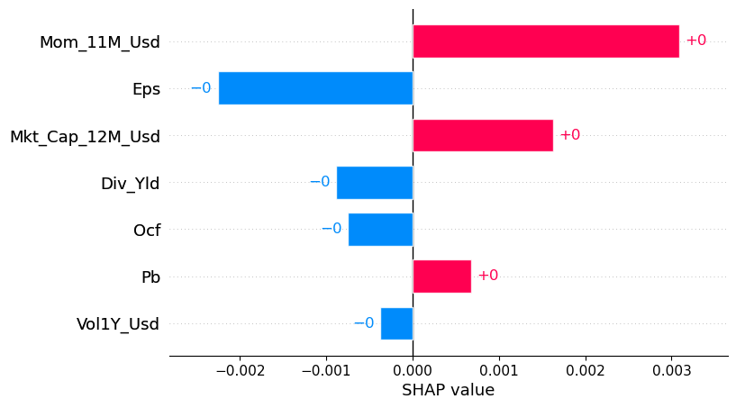

```python
import shap
explainer = shap.explainers.Exact(fit_RF_short.predict,                       # Compute the Shapley values...
                                  training_sample[features_short].values,     # Training data
                                  feature_names=features_short)               # features names, could be passed by the predictor fn as well
shap_values = explainer(training_sample[features_short].values[:1,])         # On the first instance
shap.plots.bar(shap_values[0])                                                # Visual display
```

图 13.6：Shapley 方法图解。

图 13.6 的输出给出两项关键信息：相对于基准预测，各特征对当前样本预测的贡献**方向**和**大小**。这是局部预测归因，不能直接解释为特征的全局重要性或因果效应。

### 13.2.3 分解

分解法（参见 Staniak 和 Biecek (2018)）结合了 PDP 与 Shapley 值的思想。其核心是式（13.4）定义的**放宽模型预测**，与式（13.1）的思路相近。区别在于，这里进行的是局部分析，即针对某个具体观测 $x^∗$。为了衡量一组预测变量对 $x^∗$ 对应预测的影响，把特征分为两个集合：固定特征 $\mathbf{k}$ 和自由特征 $\mathbf{-k}$。接着估计模型 $\hat{f}$ 的平均预测，其中集合 $\mathbf{k}$ 中的预测变量固定为 $x^*$ 的对应取值，也就是下面表达式中的 $x^*_{\textbf{k}}$：

\begin{equation} \tag{13.4} \tilde{f}_{\textbf{k}}(x^*)=\frac{1}{M}\sum_{m=1}^M \hat{f}\left(x^{(m)}_{-\textbf{k}},x^*_{\textbf{k}} \right). \end{equation}

上述表达式中的 $x^{(m)}$ 可以是模拟样本，也可以是从数据集中直接抽取的样本。该记号表示把样本中的部分取值替换为 $x^*$ 的对应取值，所替换位置的索引属于 $\mathbf{k}$。当 $\mathbf{k}$ 包含全部特征时，$\tilde{f}_{\textbf{k}}(x^*)$ 就等于原模型预测 $\hat{f}(x^*)$；当 $\mathbf{k}$ 为空集时，它等于标签的样本均值，也就是常数预测。

我们关心的是特征 $j\notin \textbf{k}$ 相对于数据点 $x^∗$ 和集合 $\mathbf{k}$ 的贡献：

\begin{align} \phi_{\textbf{k}}^j(x^*)=\tilde{f}_{\textbf{k} \cup j}(x^*)-\tilde{f}_{\textbf{k}}(x^*). \end{align}

与 Shapley 值类似，该指标衡量把特征 $j$ 加入预测变量集合后产生的平均影响。按定义，它依赖集合 $\mathbf{k}$；这一点不同于遍历所有排列的 Shapley 值。Staniak 和 Biecek (2018) 设计了一套逐步增加或减少集合 $\mathbf{k}$ 的贪心过程，避免枚举所有特征组合，从而降低计算负担。该算法还有一个方便的性质：所有特征贡献之和等于预测值：

\begin{align} \sum_j \phi_{\textbf{k}}^j(x^*)=f(x^*). \end{align}

可视化使这一点非常容易看到（如下图 13.7 所示）。

为演示分解法的实现，下面只用少量特征训练随机森林，以提高分解结果的可读性。

```python
fit_RF_short = RandomForestRegressor(n_estimators=12,                    # Nb of random trees
                                     criterion='squared_error',          # function to measure the quality of a split
                                       min_samples_leaf=250,             # Minimum size of terminal cluster
                                       max_features=4,                   # Nb of predictive variables for each tree
                                       bootstrap=True,                   # No replacement
                                       max_samples=10000)                # Size of (random) sample for each tree

fit_RF_short.fit(training_sample[features_short],training_sample['R1M_Usd'].values) # fitting the model
```

```
RandomForestRegressor(max_features=4, max_samples=10000, min_samples_leaf=250,
                      n_estimators=12)
```

模型训练完成后，生成预测分解的语法很简单。

```python
import dalex as dx                                                      # Module for former breakdown package (initially in R)
ex = dx.Explainer(                                                      # Creating the explainer
    model=fit_RF_short,                                                 # prediction function
    data=training_sample[features_short],
    y=training_sample['R1M_Usd'].values,
    label='fit_RF_short')

instance=pd.DataFrame(training_sample.loc[0,features_short]).T          # Transpose to adapt to requiered format
pp=ex.predict_parts(instance, type='break_down')                        # Compute the breakdown
pp.plot()                                                               # Visual display
```

[output not shown]

```
X does not have valid feature names, but RandomForestRegressor was fitted with feature names
```

```
  -> residuals         : min = -0.94, mean = 0.000344, max = 27.2
  -> model_info        : package sklearn

A new explainer has been created!
```

[interactive chart not shown]

图 13.7：分解输出示例。

图形输出很直观：灰色条表示模型对所选样本的预测，绿色条表示正向贡献，红色条表示负向贡献；各条的相对长度反映特征的重要性。

### 参考文献

Belle, Vaishak, and Ioannis Papantonis. 2020. “Principles and Practice of Explainable Machine Learning.” arXiv Preprint, no. 2009.11698.

Chen, Jianbo, Le Song, Martin J Wainwright, and Michael I Jordan. 2018. “L-Shapley and c-Shapley: Efficient Model Interpretation for Structured Data.” arXiv Preprint, no. 1808.02610.

Fisher, Aaron, Cynthia Rudin, and Francesca Dominici. 2019. “All Models Are Wrong, but Many Are Useful: Learning a Variable’s Importance by Studying an Entire Class of Prediction Models Simultaneously.” Journal of Machine Learning Research 20 (177): 1–81.

Friedman, Jerome H. 2001. “Greedy Function Approximation: A Gradient Boosting Machine.” Annals of Statistics, 1189–1232.

Gower, John C. 1971. “A General Coefficient of Similarity and Some of Its Properties.” Biometrics, 857–71.

Hall, Patrick, and Navdeep Gill. 2019. An Introduction to Machine Learning Interpretability - Second Edition. O’Reilly.

Lundberg, Scott M, and Su-In Lee. 2017. “A Unified Approach to Interpreting Model Predictions.” In Advances in Neural Information Processing Systems, 4765–74.

Molnar, Christoph. 2019. Interpretable Machine Learning: A Guide for Making Black Box Models Explainable. LeanPub / Lulu.

Molnar, Christoph, Giuseppe Casalicchio, and Bernd Bischl. 2018. “Iml: An R Package for Interpretable Machine Learning.” Journal of Open Source Software 3 (27): 786.

Ribeiro, Marco Tulio, Sameer Singh, and Carlos Guestrin. 2016. “Why Should I Trust You?: Explaining the Predictions of Any Classifier.” In Proceedings of the 22nd Acm Sigkdd International Conference on Knowledge Discovery and Data Mining, 1135–44. ACM.

Shapley, Lloyd S. 1953. “A Value for N-Person Games.” Contributions to the Theory of Games 2 (28): 307–17.

Staniak, Mateusz, and Przemyslaw Biecek. 2018. “Explanations of Model Predictions with Live and breakDown Packages.” arXiv Preprint, no. 1804.01955.

Vidal, Thibaut, Toni Pacheco, and Maximilian Schiffer. 2020. “Born-Again Tree Ensembles.” arXiv Preprint, no. 2003.11132.

Zhao, Qingyuan, and Trevor Hastie. 2020. “Causal Interpretations of Black-Box Models.” Journal of Business & Economic Statistics Forthcoming.

1. 例如，我们没有提及 Horel 和 Giesecke (2019) 的工作，但感兴趣的读者可以看看他们在神经网络方面的工作（以及论文中引用的参考文献）。↩︎